# Bicycle Rentals exploration by Sreejith Gopinath

All of these plots reinforce the findings that we reached using earlier histograms and plots. Now, in order to build a linaear model to predict bicycle ridership, I’m going to decide on a set of variables that correlate with ridership.

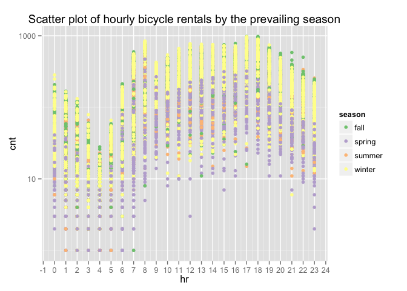

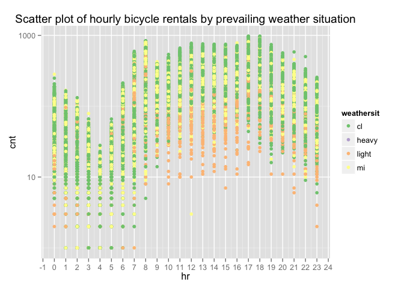

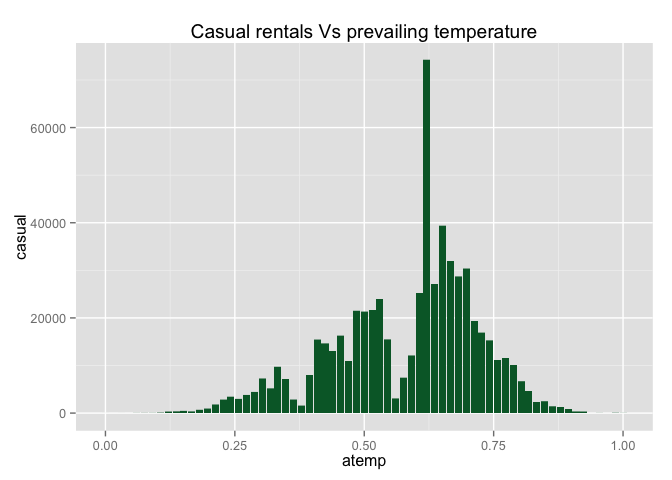

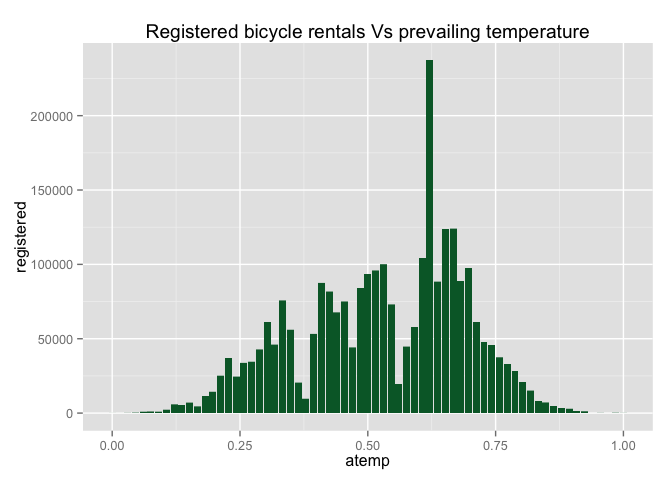

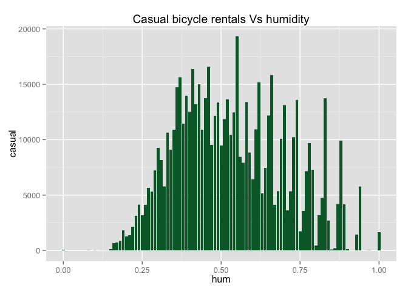

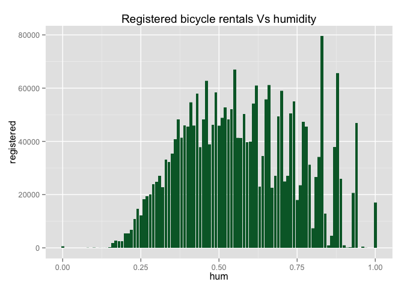

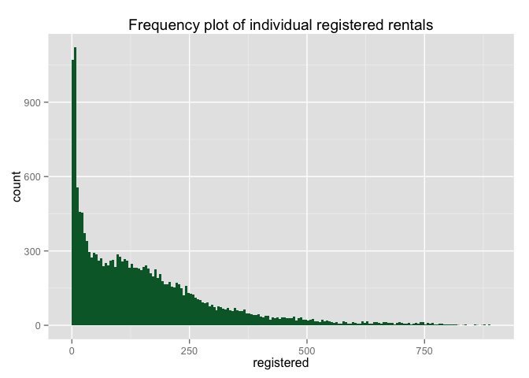

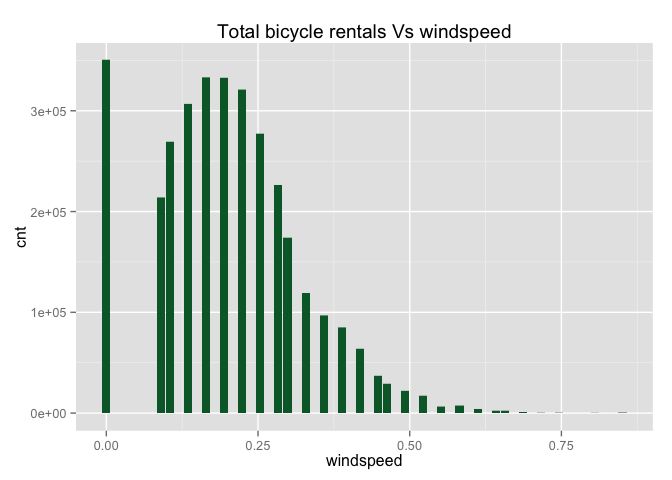

From the plots above and the r^2 values of the linear models above, I can deduce that the features that may help us predict total bicycle rentals on any given day are “registered”, “temp”, “hr”, “season”, “weathersit”, in the order of confidence. Let’s try to build a linear prediction model using these features and see if we can predict bicycle rental numbers with a high level of confidence.

```
##
## Calls:
## m1: lm(formula = I(cnt) ~ I(registered), data = df_master)
## m2: lm(formula = I(cnt) ~ I(registered) + temp, data = df_master)
## m3: lm(formula = I(cnt) ~ I(registered) + temp + hr, data = df_master)
## m4: lm(formula = I(cnt) ~ I(registered) + temp + hr + season, data = df_master)
## m5: lm(formula = I(cnt) ~ I(registered) + temp + hr + season + weathersit,
##     data = df_master)
## m6: lm(formula = I(cnt) ~ I(registered) + temp + hr + season + weathersit +
##     windspeed, data = df_master)
##
## ===================================================================================================
##                            m1           m2           m3           m4           m5           m6
## ---------------------------------------------------------------------------------------------------
## (Intercept)            10.296***    -25.759***   -33.535***   -56.904***   -53.708***   -55.745***
##                        (0.460)       (0.835)      (0.920)      (1.857)      (1.866)      (1.884)
## I(registered)           1.165***      1.129***     1.114***     1.112***     1.109***     1.108***
##                        (0.002)       (0.002)      (0.002)      (0.002)      (0.002)      (0.002)
## temp                                 83.584***    83.145***   109.100***   107.789***   107.100***
##                                      (1.661)      (1.644)      (2.622)      (2.611)      (2.609)
## hr                                                 0.893***     0.805***     0.827***     0.796***
##                                                   (0.046)      (0.047)      (0.047)      (0.047)
## season: spring/fall                                            18.307***    18.247***    17.099***
##                                                                (1.332)      (1.326)      (1.333)
## season: summer/fall                                            16.161***    16.560***    15.863***
##                                                                (0.924)      (0.920)      (0.923)
## season: winter/fall                                            13.241***    13.651***    13.454***
##                                                                (1.111)      (1.107)      (1.105)
## weathersit: heavy/cl                                                         0.538        0.633
##                                                                            (22.388)     (22.355)
## weathersit: light/cl                                                       -12.852***   -13.401***
##                                                                             (1.103)      (1.104)
## weathersit: mi/cl                                                           -5.546***    -5.379***
##                                                                             (0.683)      (0.683)
## windspeed                                                                                17.916***
##                                                                                          (2.470)
## ---------------------------------------------------------------------------------------------------
## R-squared                    0.945        0.952        0.953        0.954        0.954        0.955
## adj. R-squared               0.945        0.952        0.953        0.954        0.954        0.954
## sigma                       42.511       39.716       39.302       38.948       38.759       38.701
## F                       299011.649   172556.049   117596.137    59925.300    40359.602    36436.869
## p                            0.000        0.000        0.000        0.000        0.000        0.000
## Log-likelihood          -89825.690   -88643.242   -88460.671   -88301.904   -88215.940   -88189.651
## Deviance              31402836.983 27407601.645 26837762.249 26351857.617 26092447.751 26013625.792
## AIC                     179657.381   177294.484   176931.343   176619.808   176453.880   176403.301
## BIC                     179680.670   177325.536   176970.158   176681.913   176539.274   176496.457
## N                        17379        17379        17379        17379        17379        17379
## ===================================================================================================
```

To the variables I mention in the section above, I added the “windspeed” variable to see if factoring it in would give my prediction model some more accuracy. We see that the prediction model I just built can help predict bicycle rentals on a given day with about 95.5% confidence.

# Multivariate Analysis

*Talk about some of the relationships you observed in this part of the investigation. Were there features that strengthened each other in terms of looking at your feature(s) of interest?*  
Many of the variables interact and strengthen each others’ influence over bicycle rental numbers. For example, temperature, humidity and windspeed are tightly related to the weather situation. Each season has a weather situation that dominates a majority of the days in that season.

*Were there any interesting or surprising interactions between features?*  
I did not see any surprising relationships between features in the dataset.

*Did you create any models with your dataset? Discuss the strengths and limitations of your model.*  
Yes, I created a prediction model with the dataset. The main strength of my prediction model is that it is able to predict bicycle rental numbers with about 95.5% confidence. Some limitations of the model:  
1) The dataset spans only about two years. As we collect more and more data, we may need to tweak the model.  
2) The model does not take into account any special events happening in the city on a given day(this is actually a limitation of the dataset!). If we know whether there were any significant events in the city(rally, game, etc.) on a given day, we could have used that as an input into our model.

# Final Plots and Summary

## Plot One

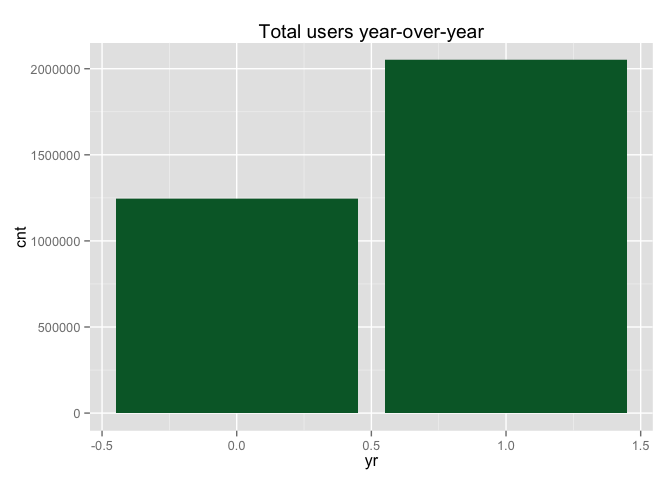

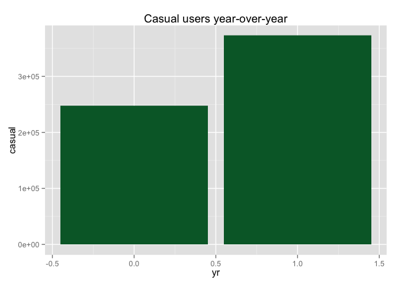

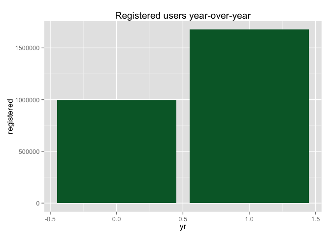

## Description One

From the preceding plots, we see that there is definitely an uptick in the number of bicycle rentals year-over-year. We also see that the gap between casual and registered users increases year-over-year. Therefore, we can safely say that the popularity of the bicycle rental service has clearly from the initial year to the next.

## Plot Two

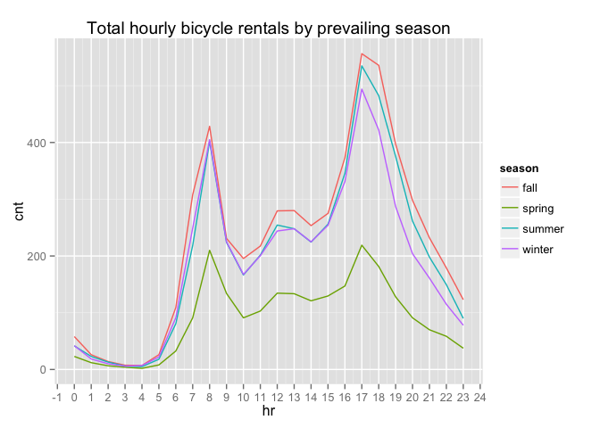

## Description Two

In the previous plot, we see the hourly trends for bicycle rentals across all the observations in the dataset, colored by seasons. In all seasons, we see that one of the hours peaks occurs at 8:00 AM and the second one at 5:00 PM. These peaks suggest that bicycle rentals are utilized by users who use the bikes to get to work/school(since these activities tend to be between fixed times everyday). We see that the cicycle rental numbers fall on either side of the peak, marking their lowest points during the night hours. The general trend holds in all seasons, but the numbers are highest in the fall, followed by summer, winter and spring. I think this is mainly because of temperature, precipitation and other factors associated with the seasons.

## Plot Three

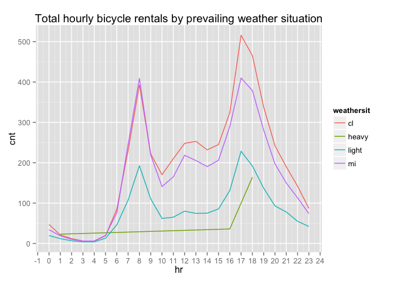

## Description Three

In the previous plot, we see hourly trends for bicycle rentals across all observations in the dataset, colored by the prevailing weather situation. The trends we see in the previous plot are, to some extent, seen in this plot too. Let’s consider the three weather situations - clear, mild and light precipitation first. We see the conventional “commuter peaks” at 8:00 AM and 5:00PM, with ridership falling off on either sides of the peaks. Interestingly, renter behavior is very different during periods of heavy precipitation. Total rentals during heavy precipitation stays close to none in the early hours of the day, peaking slightly at around 6:00 PM.

# Reflection

The bicycle rentals dataset consists of 17379 hourly observations of bicycle rentals at a rental agency in Washington DC. I chose this dataset because I wanted to gain some experience in choosing a tidy dataset to explore. I see that it is mostly weather-related features that closely influence the bicycle rental numbers on a given day. Factors like temperature, precipitation and windspeed tie closely into the prevailing weather situations and seasons. Therefore, to some extent, these factors influence and strengthen each other. Another feature that influences bicycle rentals is the hour of the day. I think this may be driven by office/school-goers who use bicycles to commute - and I see peaks occuring at the conventional working hours. Also, as expected, we see lesser bicycle rentals during the cold season and during periods of heavy precipitation.  
I was able to put together a linear prediction model for bicycle rentals. The model is able to predict bicycle rentals with a 95% confidence level.  
In conclusion, I would like to correlate this data with events that happened in Washington DC. on each of these days. That would help me see if casual bicycle rentals were driven by people wanting to avoid event-driven crowds on the popular transportation systems. also, I would love to explore the data for a few more years than contained in this dataset.